# Praca domowa 3

Jakub Kasprzak, Tymoteusz Barciński

21 11 2021

# Przedstawienie wyników pracy domowej 3 z przedmiotu Techniki Wizualizacji Danych.

Przedmiotem pracy domowej było przeprowadzenie eksperymentów dotyczących problemów z odbiorem treści przy prezentacji danych na wykresach. Przeprowadziliśmy dwa eksperymenty i udało nam się uzyskać 26 odpowiedzi od osób w różnym wieku, o różnym wykształceniu i kontakcie z wizualizacją danych. Ankietę przeprowadzaliśmy przy użyciu platformy Google Forms.

## Eksperyment 1

Pierwszy z przeprowadzonych przez nas eksperymentów dotyczył różnic w odbiorze wykresów, w tym wypadku map, na których zastosowano różne skale kolorów: intensywną i stonowaną.

### Wykresy

Oba wykresy przedstawiały dokładnie te same dane, czyli logarytm liczby ludności w krajach na świecie (dane zostały zaczerpnięte z ramki `countries` z pakietu `SmarterPoland`). Na pierwszym wykresie zastosowaliśmy dość jaskrawy i intensywny kolor zielony, a na drugim jego bardziej stonowany i ciemniejszy odpowiednik.

**Wykres 1**

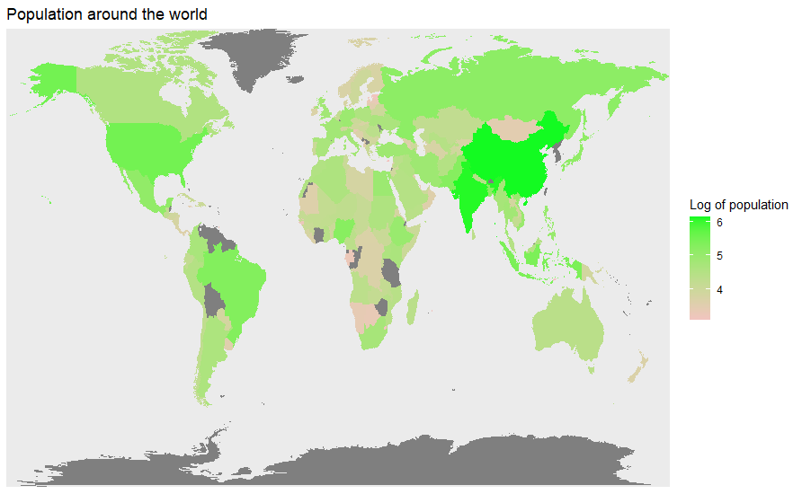

**Wykres 2**

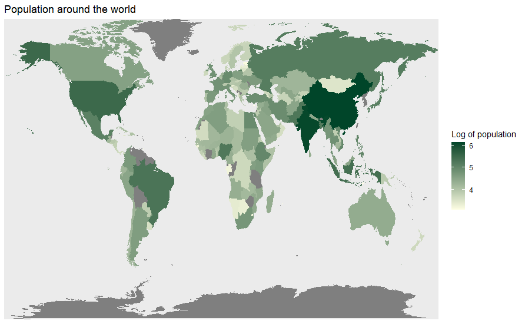

### Pytania

**Pytanie 1**

Pierwsze pytanie było identyczne dla każdego z wykresów i brzmiało “Jak łatwo jest odczytać dane na wykresie?”. Odpowiedzi przyjmowaliśmy w skali od 1 (trudno) do 5 (łatwo). Poniżej można zobaczyć wykresy prezentujące wyniki ankiety:

**Wykres 1**

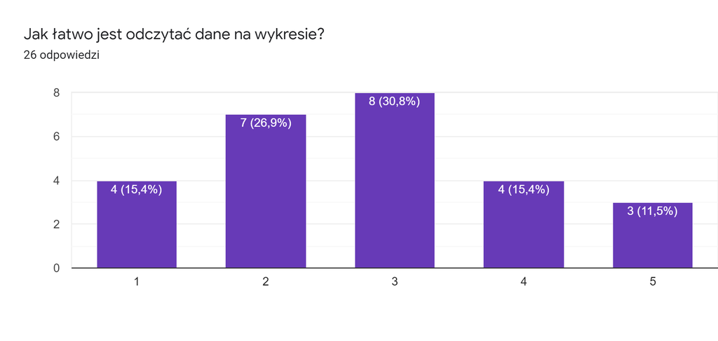

**Wykres 2**

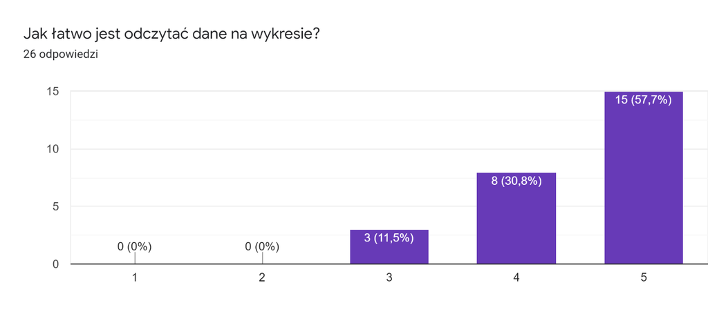

**Pytanie 2**

Drugie pytanie polegało na wybraniu jednego z wykresów i brzmiało “Który jest przyjemniejszy w odbiorze?”. Wszystkie 26 osób ankietowanych wybrało wykres 2.

#### Podsumowanie eksperymentu 1

Wyniki eksperymentu wyraźnie wskazują, że stonowane kolory na wykresie tego typu są znacząco preferowane przez ankietowanych. Warto wspomnieć, że wśród osób ankietowanych nie było osoby, która lepiej oceniłaby wykres 1 – wszystkie trzy osoby, które przyznały mu ocenę 5, tak samo oceniły wykres 2. Sugeruje to, w szczególności w połączeniu z wynikami pytania 2., że osoby ankietowane stanowczo preferowały wykres z kolorami stonowanymi.

## Eksperyment 2

Drugi z przeprowadzonych przez nas eksperymentów miał za zadanie sprawdzić preferencje ankietowanych dotyczące osi, na której umieszczone są zmienne kategoryczne.

### Wykresy

Na obu wykresach umieszone zostały te same [dane z portalu ourworldindata.com](https://ourworldindata.org/grapher/projected-population-by-country) dotyczące liczby ludności w wybranych krajach europejskich.

**Wykres 1**

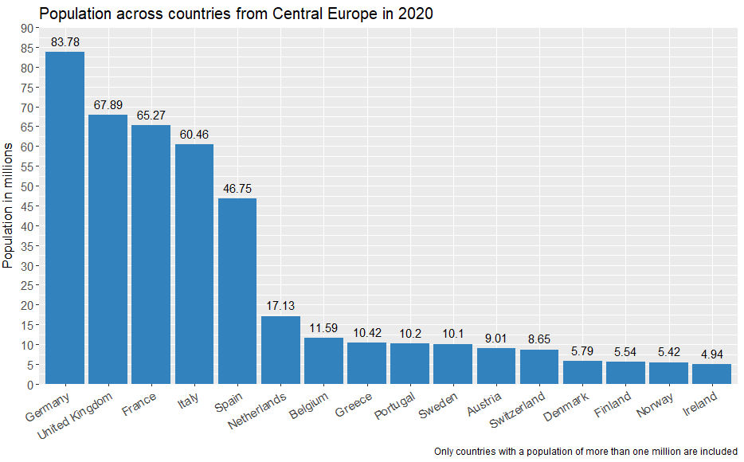

**Wykres 2**

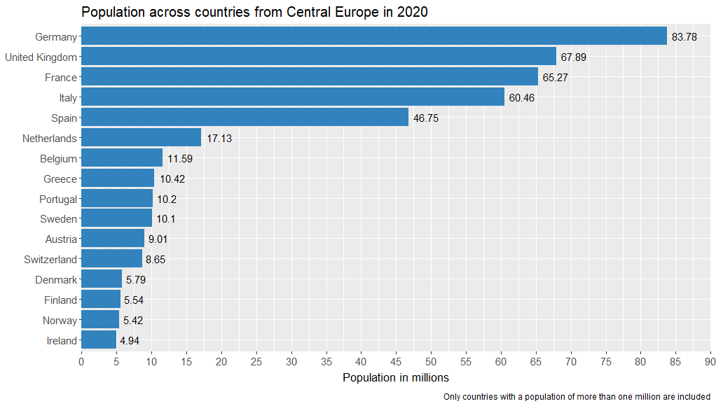

### Pytania

**Pytanie 1**

Pytanie 1 było wspólne dla obu wykresów i analogiczne dla pierwszego eksperymentu. Brzmiało “Jak łatwo jest odczytać dane na wykresie?”, a możliwe były odpowiedzi w skali od 1 (trudno) do 5 (łatwo). Poniżej można zobaczyć wykresy prezentujące wyniki ankiety:

**Wykres 1**

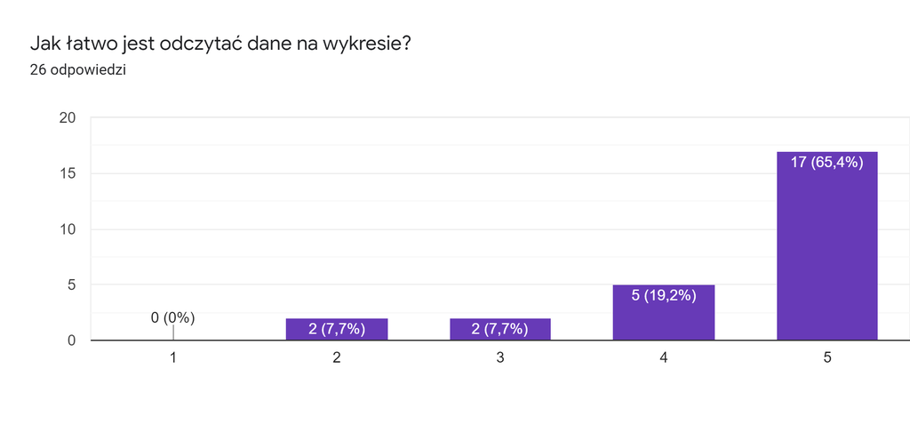

**Wykres 2**

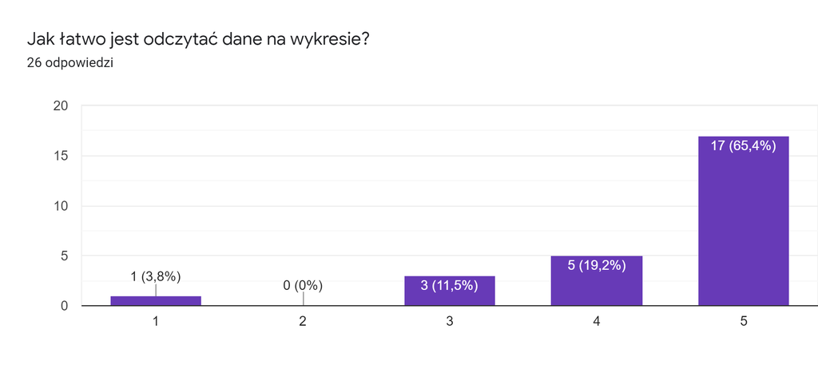

**Pytanie 2**

Drugie pytanie polegało na wybraniu jednego z dwóch wykresów i brzmiało “Jakie są Twoje preferencje odnośnie umiejscowienia nazw krajów? Który wykres jest przyjemniejszy w odbiorze?”. Każdy z wykresów otrzymał po 13 głosów, czyli po 50%.

#### Podsumowanie eksperymentu 2

Wyniki eksperymentu pokazują, że, przynajmniej dla naszej grupy badawczej, nie ma “lepszego” sposobu na przedstawienie tych danych. Oba wykresy otrzymały po tyle samo ocen ‘5’, również średnia i mediana z każdego z głosowań jest taka sama (średnia – 4.423, mediana – 5). Nie udało się zatem rozstrzygnąć, które z przedstawień jest bardziej czytelne i łatwiejsze w odbiorze. Prawdopodobnie należałoby przeprowadzić ankietę na większej grupie badawczej żeby móc wyciągnąć dalsze wnioski.

### Standard IBCS

Zadaliśmy też ankietowanym dodatkowe pytanie – “Czy zetknąłeś się z zaleceniami Międzynarodowego Standardu Komunikacji Biznesowej (ang. IBCS)?”, aby zorientować się, na ile ankietowani są związani z wizualizacją danych. Jedynie czworo z nich udzieliło twierdzącej odpowiedzi, co sugeruje, że większość (84,6%) osób odpowiadających nie ma dodatkowej wiedzy teoretycznej na temat wizualizacji danych i odbiera wykresy jedynie intuicyjnie. Było to o tyle istotne, że ten standard nakazuje umieszczanie zmiennych kategorycznych na osi pionowej, więc wiedza, na ile ankietowani mieli z nim styczność, była dość ważna.

## Podsumowanie

Oba eksperymenty udało się przeprowadzić na większej grupie niż minimalna wymagana, co pozwoliło na uzyskanie bardziej rzetelnych wyników. Wynik pierwszego eksperymentu jest zgodny z przewidywaniami i fakt, że aż 100% ankietowanych opowiedziała się za drugim wykresem, jedynie potwierdza, że stonowane kolory są łatwiejsze w analizowaniu niż ich jaskrawe odpowiedniki. Drugi eksperyment pokazał natomiast, że preferencja dotycząca umiejscowienia zmiennych kategorycznych jest kwestią czysto subiektywną i żadne z przedstawień danych nie jest bardziej pożądane od drugiego.